# R-Assignment-BCB546-Spring2021-Topping

Nick Topping

3/17/2021

## R Assignment

To start, create a repository on GitHub. My repository is named R-Assignment-BCB546-Spring2021-Topping. To load the working repository into R Studio:

1. Clone the repository to your clipboard
2. Open R Studio and click File, New Project, Version Control, Git
3. Paste the repository URL, fill in the directory name and click Create Project

Then, install and load any R packages needed for this assignment. You will need `tidyverse`, `ggplot2`, and `stringr`. Use `install.packages("package")` and load it into your library if not installed

```r
library(tidyverse)
```

```r
library(ggplot2)
library(tidyr)
library(dplyr)
library(stringr)
```

### Data Extraction and Modification

Next, open both data files, `fang_et_al_genotypes` and `snp_position.txt`. Both of these files can be found in the BCB-546-Spring2021 github repository, with the links below in the code. Transform the files into a data frame with the code below:

```r
fang_et_al_genotypes <- read.table("https://raw.githubusercontent.com/EEOB-BioData/BCB546-Spring2021/master/assignments/UNIX_Assignment/fang_et_al_genotypes.txt", header = TRUE,)
snp_position <- read.table("https://raw.githubusercontent.com/EEOB-BioData/BCB546-Spring2021/master/assignments/UNIX_Assignment/snp_position.txt", header = TRUE, sep = "\t")
```

To quickly look at the data files, double click on them in the Environment. This will show the data in a .txt file that you can see.

Note: You can also use the function `view(fang_et_al_genotypes)` to show the data, but it isn’t working in my markdown file for some reason…

### Below are a few codes you can use to inspect the data

`object.size()` shows the file size of the data frame

`nrow()` shows the number of rows

`ncol()` shows the number of columns

`dim()` shows the dimensions of the data frame by row and column

`head()` show first 6 rows

`tail()` shows last 6 rows

`str()` shows the structure of the data frame: the name, type and preview of data in each column

`names()` shows the names attributes for the data frame, which are also the column names

The function `colnames()` also will show the column names

`sapply(dataframe, class)` shows the class of each column of data

### fang_et_al_genotypes

```r
object.size(fang_et_al_genotypes)
```

[output not shown]

```r
nrow(fang_et_al_genotypes)
```

```
## [1] 2782
```

```r
ncol(fang_et_al_genotypes)
```

[output not shown]

```r
dim(fang_et_al_genotypes)
```

```
## [1] 2782  986
```

Note: The output for functions `head()` `tail()` `str()` `names()` and `sapply(dataframe, class)` are not included in this markdown file for this data table as these outputs are very long and clutter the console

### snp_position

```r
object.size(snp_position)
```

```
## 327392 bytes
```

```r
nrow(snp_position)
```

```
## [1] 983
```

```r
ncol(snp_position)
```

```
## [1] 15
```

```r
dim(snp_position)
```

```
## [1] 983  15
```

```r
str(snp_position)
```

```
## 'data.frame':    983 obs. of  15 variables:
##  $ SNP_ID              : chr  "abph1.20" "abph1.22" "ae1.3" "ae1.4" ...
##  $ cdv_marker_id       : int  5976 5978 6605 6606 6607 5982 3463 3466 5983 5985 ...
##  $ Chromosome          : chr  "2" "2" "5" "5" ...
##  $ Position            : chr  "27403404" "27403892" "167889790" "167889682" ...
##  $ alt_pos             : chr  "" "" "" "" ...
##  $ mult_positions      : chr  "" "" "" "" ...
##  $ amplicon            : chr  "abph1" "abph1" "ae1" "ae1" ...
##  $ cdv_map_feature.name: chr  "AB042260" "AB042260" "ae1" "ae1" ...
##  $ gene                : chr  "abph1" "abph1" "ae1" "ae1" ...
##  $ candidate.random    : chr  "candidate" "candidate" "candidate" "candidate" ...
##  $ Genaissance_daa_id  : int  8393 8394 8395 8396 8397 8398 8399 8400 8401 8402 ...
##  $ Sequenom_daa_id     : int  10474 10475 10477 10478 10479 10481 10482 10483 10486 10487 ...
##  $ count_amplicons     : int  1 0 1 0 0 1 1 0 1 0 ...
##  $ count_cmf           : int  1 0 1 0 0 1 0 0 1 0 ...
##  $ count_gene          : int  1 0 1 0 0 1 1 0 1 0 ...
```

```r
names(snp_position)
```

```
##  [1] "SNP_ID"               "cdv_marker_id"        "Chromosome"
##  [4] "Position"             "alt_pos"              "mult_positions"
##  [7] "amplicon"             "cdv_map_feature.name" "gene"
## [10] "candidate.random"     "Genaissance_daa_id"   "Sequenom_daa_id"
## [13] "count_amplicons"      "count_cmf"            "count_gene"
```

```r
sapply(snp_position, class)
```

```
##               SNP_ID        cdv_marker_id           Chromosome
##          "character"            "integer"          "character"
##             Position              alt_pos       mult_positions
##          "character"          "character"          "character"
##             amplicon cdv_map_feature.name                 gene
##          "character"          "character"          "character"
##     candidate.random   Genaissance_daa_id      Sequenom_daa_id
##          "character"            "integer"            "integer"
##      count_amplicons            count_cmf           count_gene
##            "integer"            "integer"            "integer"
```

For this data table, only `head()` and `tails()` were left out of the snp_position analyses

## Data Processing

Create two new data frames sorted by the ID’s of both species from fang_et_al_genotypes with the following code:

```r
Maize_IDs <- fang_et_al_genotypes[which(fang_et_al_genotypes$Group == "ZMMIL" | fang_et_al_genotypes$Group == "ZMMLR" | fang_et_al_genotypes$Group == "ZMMMR"),]
Teosinte_IDs <- fang_et_al_genotypes[which(fang_et_al_genotypes$Group == "ZMPBA" | fang_et_al_genotypes$Group == "ZMPIL" | fang_et_al_genotypes$Group == "ZMPJA"),]
```

Then pull columns 1, 3 and 4 from the file snp_position and combine them into one

```r
SNP_Chrom_Pos <- snp_position[,c(1,3,4)]
```

The next step is to combine the data files so that the first column is “SNP_ID”, second is “Chromosome”, third is “Position”, and the rest are genotype data. In order to do this, `Maize_IDs` and `Teosinte_IDs` must be transposed, THEN combined

```r
Maize_IDs_Transposed <- as.data.frame(t(Maize_IDs[,-1]))
colnames(Maize_IDs_Transposed) <- Maize_IDs$Sample_ID
Teosinte_IDs_Transposed <- as.data.frame(t(Teosinte_IDs[,-1]))
colnames(Teosinte_IDs_Transposed) <- Teosinte_IDs$Sample_ID
```

```r
Maize_IDs_Transposed <- cbind(SNP_ID = row.names(Maize_IDs_Transposed), Maize_IDs_Transposed)
Teosinte_IDs_Transposed <- cbind(SNP_ID = row.names(Teosinte_IDs_Transposed), Teosinte_IDs_Transposed)
```

To combine the transposed data frames with the first file `SNP_Chrom_Pos` merge the files by SNP_ID

Combine the transposed data frames with the previous file `SNP_Chrom_Pos` followed by either maize or teosinte #note that the rows should stay in the same order

```r
Maize_Chromosomes <- merge(SNP_Chrom_Pos,Maize_IDs_Transposed, by = "SNP_ID")
Teosinte_Chromosomes <- merge(SNP_Chrom_Pos,Teosinte_IDs_Transposed, by = "SNP_ID")
```

```r
Maize_Chromosomes[Maize_Chromosomes=="NA"] <- "?/?"
Teosinte_Chromosomes[Teosinte_Chromosomes=="NA"] <- "?/?"
```

Sort both new files by position with the `order()` function

```r
Maize_Chromosomes_Ascending <- Maize_Chromosomes[order(suppressWarnings(as.numeric(Maize_Chromosomes$Position))), ]
Teosinte_Chromosomes_Ascending <- Teosinte_Chromosomes[order(suppressWarnings(as.numeric(Teosinte_Chromosomes$Position))), ]
Maize_Chromosomes_Descending <- Maize_Chromosomes[order(suppressWarnings(as.numeric(Maize_Chromosomes$Position, decreasing = T))), ]
Teosinte_Chromosomes_Descending <- Teosinte_Chromosomes[order(suppressWarnings(as.numeric(Teosinte_Chromosomes$Position, decreasing = T))), ]
```

### Create a function to make 10 files in one command chunk (10 for Maize and Teosinte, ascending and descending order)

```r
Filter_By_Chromosome <- function(x, df){
  df %>% filter(Chromosome == x)
}
Maize_Ascending_By_Chromosome <-
lapply(sort(unique(Maize_Chromosomes_Ascending$Chromosome)), Filter_By_Chromosome, Maize_Chromosomes_Ascending)
invisible(lapply(Maize_Ascending_By_Chromosome, function(x) write.csv(x, file = paste0("Maize_Ascending_Chromosome_", x$Chromosome[1]))))
```

```r
Maize_Descending_By_Chromosome <-
lapply(sort(unique(Maize_Chromosomes_Descending$Chromosome)), Filter_By_Chromosome, Maize_Chromosomes_Descending)
invisible(lapply(Maize_Descending_By_Chromosome, function(x) write.csv(x, file = paste0("Maize_Descending_Chromosome_", x$Chromosome[1]))))
```

```r
Teosinte_Ascending_By_Chromosome <-
lapply(sort(unique(Teosinte_Chromosomes_Ascending$Chromosome)), Filter_By_Chromosome, Teosinte_Chromosomes_Ascending)
invisible(lapply(Teosinte_Ascending_By_Chromosome,function(x) write.csv(x, file = paste0("Teosinte_Ascending_Chromosome_", x$Chromosome[1]))))
```

```r
Teosinte_Descending_By_Chromosome <-
lapply(sort(unique(Teosinte_Chromosomes_Descending$Chromosome)), Filter_By_Chromosome, Teosinte_Chromosomes_Descending)
invisible(lapply(Teosinte_Descending_By_Chromosome,function(x) write.csv(x, file = paste0("Teosinte_Descending_Chromosome_", x$Chromosome[1]))))
```

# Plots

Transform the data so that both position and chromosome are numeric

```r
Maize_Chromosomes_Numeric <- transform(Maize_Chromosomes, Chromosome =as.numeric(Chromosome), Position=as.numeric(Position))
Teosinte_Chromosomes_Numeric <- transform(Teosinte_Chromosomes, Chromosome =as.numeric(Chromosome), Position=as.numeric(Position))
```

### Plot the number of SNP’s on each chromosome from the `snp_position` dataset

Tidy up the data using the `pivot_longer()` function. Then merge the pivoted data with the SNP position data and make the data table numeric by chromosome.

```r
fang_pivot <- fang_et_al_genotypes %>% pivot_longer(!c(Sample_ID, JG_OTU, Group), names_to="SNP_ID", values_to= "NT")
merge_fang_pivot <- merge(fang_pivot, snp_position, by="SNP_ID")
merge_fang_pivot_numeric <- merge_fang_pivot[!is.na(as.numeric(merge_fang_pivot$Chromosome)),]
```

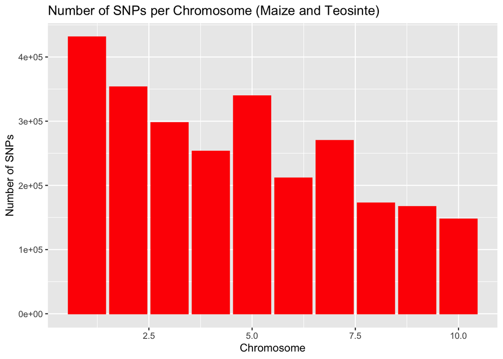

```r
merge_fang_pivot_numeric %>%
  select(SNP_ID, Chromosome, Position) %>%
  drop_na() %>%
  ggplot()+
  geom_bar(mapping = aes(as.numeric(Chromosome)), color="red", fill="red")+ ggtitle("Number of SNPs per Chromosome (Maize and Teosinte)") + labs(x = "Chromosome", y = "Number of SNPs")
```

### Plot the distribution of SNPs along each chromosome by group based on Position values

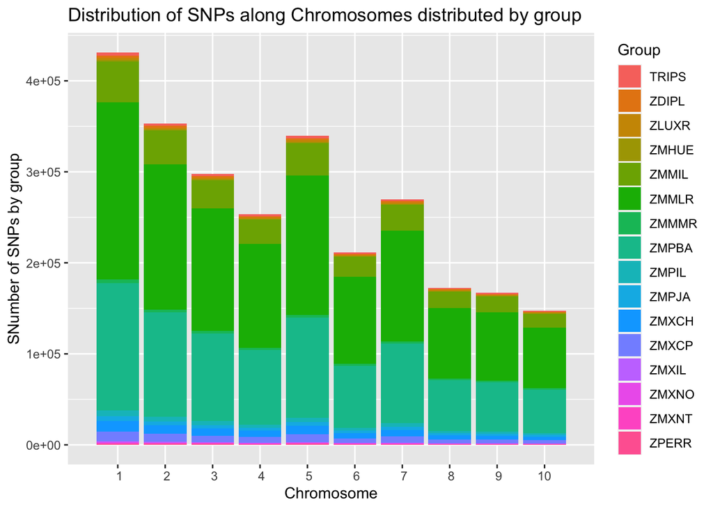

```r
ggplot(data = merge_fang_pivot_numeric) + geom_bar(mapping = aes(as.numeric(Chromosome), fill=Group)) + scale_x_discrete(limit=c(1:10)) + labs(x = "Chromosome", y="SNumber of SNPs by group") + ggtitle("Distribution of SNPs along Chromosomes distributed by group")
```

Add a new column to the `merge_fang_pivot_numeric` data frame called Zygosity

```r
merge_fang_pivot_numeric$Zygosity <- "Heterozygous"
```

Replace all `"?/?"` with `Missing Data` in the Zygosity column

```r
merge_fang_pivot_numeric$Zygosity[merge_fang_pivot_numeric$NT == "?/?"] <- "Missing Data"
```

For every “A/A”, “C/C”, “G/G”, “T/T” site replace the value in the Zygosity column with `Homozygous`

```r
merge_fang_pivot_numeric$Zygosity[merge_fang_pivot_numeric$NT %in% c("A/A", "C/C", "G/G", "T/T")] <- "Homozygous"
```

Plot the data of the proportion of heterozygous and homozygous sites, and missing data sites by Sample ID

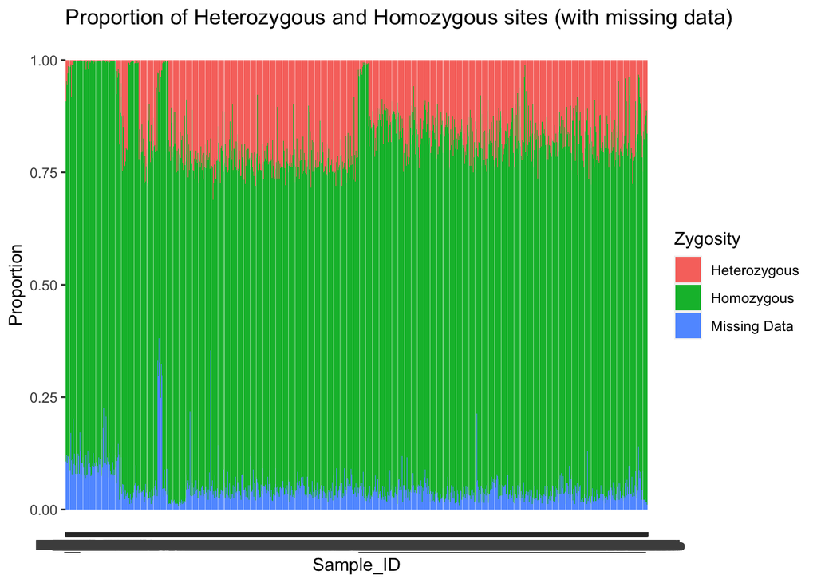

```r
ggplot(data = merge_fang_pivot_numeric) + geom_bar(mapping=aes(x = Sample_ID, fill = Zygosity), position = "fill") + labs(x = "Sample_ID", y="Proportion") + ggtitle("Proportion of Heterozygous and Homozygous sites (with missing data)")
```

Plot the data of the proportion of heterozygous and homozygous sites, and missing data sites by group

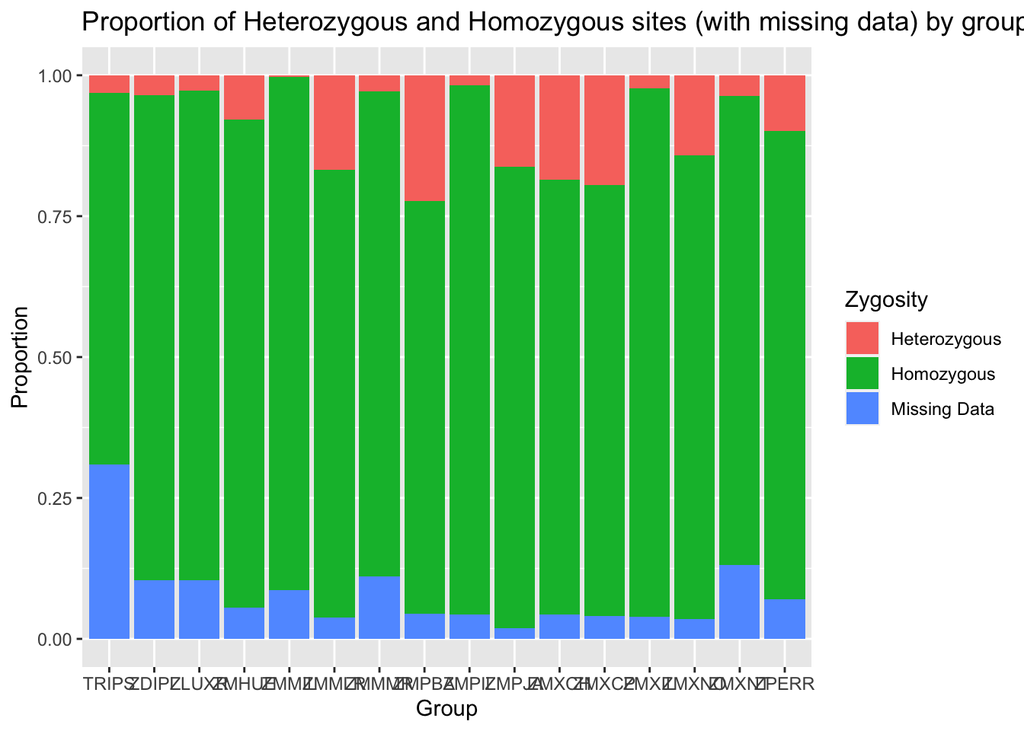

```r
ggplot(data = merge_fang_pivot_numeric) + geom_bar(mapping = aes(x = Group, fill = Zygosity), position = "fill") + labs(x = "Group", y="Proportion") + ggtitle("Proportion of Heterozygous and Homozygous sites (with missing data) by group")
```

## My own data visualization

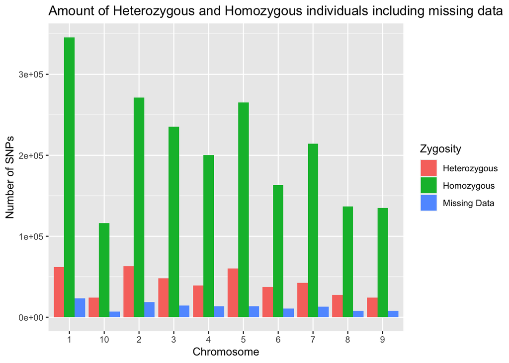

```r
   ggplot(data = merge_fang_pivot_numeric) + geom_bar(mapping=aes(x = Chromosome, fill=Zygosity), position="dodge") + labs(x = "Chromosome", y="Number of SNPs") + ggtitle("Amount of Heterozygous and Homozygous individuals including missing data")
```